# Live coding 6

Andrew Irwin

2021-02-11 8:35

# Agenda

- Questions arising from lessons, tasks
- Examples from lessons 15-17: linear models and smooths

The plan for the live coding is for us to work together to solve problems using tools from this week’s lessons. As with last week, we’ll start with some repeated examples from lessons to remind ourselves of the basics, then try to use the tools in new ways, and finally switch perspectives to try to solve a real problem with each tool.

In this live coding session I will focus mostly on adding lines and smooths to a scatterplot. We can look at `lm`, `gam`, `loess`, `augment`, `tidy` and `glance` functions for working with models outside of a visualization too.

## Linear models: linear regression

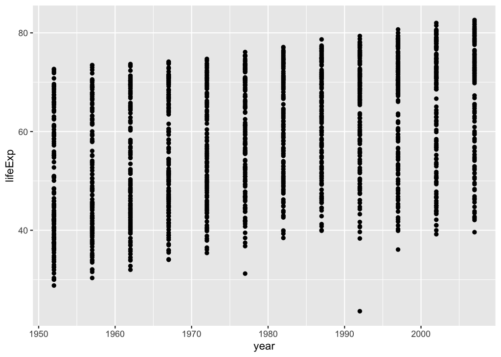

```r
gapminder %>% ggplot(aes(x = year, y = lifeExp, group = country)) + geom_point()
```

Put each continent on its own facet. Add a smooth for each continent. Show the country data as lines. Make the country lines fade into the background.

## Linear models: other regression lines

Polynomials. Log transforms. Other transformations?

What is the relationship between penguin body mass and flipper length? Is this the same for each species? For male and female penguins?

## Linear models: quantile regression

Find the quantile regression lines for life expectancy within Europe over time.

```r
quantreg::rq(lifeExp ~ year,
             data = gapminder %>% filter(continent == "Europe"),
             tau = c(0.25, 0.50, 0.75))
```

```
## Call:
## quantreg::rq(formula = lifeExp ~ year, tau = c(0.25, 0.5, 0.75),
##     data = gapminder %>% filter(continent == "Europe"))
##
## Coefficients:
##             tau= 0.25    tau= 0.50  tau= 0.75
## (Intercept) -303.6256 -357.4799714 -353.61705
## year           0.1888    0.2173429    0.21615
##
## Degrees of freedom: 360 total; 358 residual
```

## GAM smooths

Is a GAM or linear model better (judged by the visualization) for the relationship between life expectancy and year? life expectancy and GDP per capita?

## Getting model parameters

Use `lm`, `loess` together with `tidy`, `glance`, and `augment` to get model parameters, residuals, and fitted values.